# GSEA Pretty Plots

Anna Jaeschke Twitter: @anna_jaey Github: anna-jaey

21/08/2020

# Pretty Plots for GSEA results

This is a step-by-step protocol on how to use R for gene set enrichment analysis and visualisation. We use the api for the **D**atabase for **A**nnotation, **V**isualization and **I**ntegrated **D**iscovery [**DAVID**](https://david.ncifcrf.gov/) for functional annotation and annotation clustering of a gene list. Then, using the `GOplot` package the data is prepared for plotting. Finally, functional annotation results and clusters will be plotted using graphs developed on the basis of the `GOplot` package.

To compile this `rmd` document, make sure to register for the DAVID api and change the email adress (see below). Be aware that knitting the `rmd` doc might take a couple of minutes.

## Packages

```r
packages <- c("openxlsx",
              "RDAVIDWebService",
              'GOplot',
              'stringr',
              'dplyr',
              'ggplot2',
              'ggrepel',
              'ggnewscale',
              'grid')
pck.check <- lapply(
  packages,
  FUN = function(x) {
    if (!require(x, character.only = TRUE)) {
      install.packages(x, dependencies = TRUE)
      library(x, character.only = TRUE)
    }
  }
)
# source: https://vbaliga.github.io/verify-that-r-packages-are-installed-and-loaded/
```

## Read in the gene list

We start with a gene list which is dervived from a MS/MS analysis. It contains the Uniprot Accession numbers and logFC between two groups of interest. The gene list is published [DOI:10.1016/j.mtbio.2020.100073](https://doi.org/10.1016/j.mtbio.2020.100073) and we can read it directly from the url.

```r
gene.list <- read.xlsx("https://ars.els-cdn.com/content/image/1-s2.0-S2590006420300338-mmc1.xlsx", sheet = 1, startRow = 2)
# The gene list data fram contains other information/columns which are not needed
gene.list <- gene.list[,c('Accession', 'logFC.CAF:NPF')] # remove the other columns
colnames(gene.list) <- c('ID', 'logFC')
head(gene.list)
```

```
##       ID    logFC
## 1 P68402 9.590574
## 2 Q9H0V9 7.091209
## 3 Q13867 6.919214
## 4 P13612 6.328331
## 5 Q9NRW7 6.207517
## 6 P55899 6.025719
```

## RDavidWebService

We can use the `RDAVIDWebService` package to use the DAVID api from within R. It might be a little slow to use, but it’s worthwhile when working with several lists. Prepare the script, run the script and have a coffee while waiting for the results ;).

[Register here](https://david.ncifcrf.gov/webservice/register.htm) with your email address to use the DAVID Webservice.

### Prepare the connection to DAVID

```r
e_mail <- 'registered@user.com' # change to the email address you have registered with
```

```r
# create a david object
david<-DAVIDWebService$new(email = e_mail,
                           url =  'https://david.ncifcrf.gov/webservice/services/DAVIDWebService.DAVIDWebServiceHttpSoap12Endpoint/' )
```

### Functional Annotation

```r
# set the relevant annotation categories
getAllAnnotationCategoryNames(david) # view the available categories
```

```
##  [1] "ENTREZ_GENE_ID"            "BBID"
##  [3] "BIOCARTA"                  "BIOGRID_INTERACTION"
##  [5] "CGAP_EST_QUARTILE"         "CGAP_SAGE_QUARTILE"
##  [7] "CHROMOSOME"                "COG_ONTOLOGY"
##  [9] "CYTOBAND"                  "DIP"
## [11] "ENSEMBL_GENE_ID"           "EC_NUMBER"
## [13] "GAD_DISEASE"               "ENTREZ_GENE_SUMMARY"
## [15] "GENE3D"                    "GAD_DISEASE_CLASS"
## [17] "GNF_U133A_QUARTILE"        "GENERIF_SUMMARY"
## [19] "GOTERM_BP_2"               "GOTERM_BP_1"
## [21] "GOTERM_BP_4"               "GOTERM_BP_3"
## [23] "GOTERM_BP_ALL"             "GOTERM_BP_5"
## [25] "GOTERM_BP_FAT"             "GOTERM_BP_DIRECT"
## [27] "GOTERM_CC_3"               "GOTERM_CC_4"
## [29] "GOTERM_CC_1"               "GOTERM_CC_2"
```

[output cut: 20 more lines]

```r
setAnnotationCategories(david, c('GOTERM_CC_FAT',
                                 'GOTERM_MF_FAT',
                                 'GOTERM_BP_FAT',
                                 "UP_KEYWORDS",
                                 "KEGG_PATHWAY")) # set the categories

res <- addList(david,
        gene.list$ID, # genes
        idType = "UNIPROT_ACCESSION", # ID type of genes (ENTREZ, ENSEMBL, Uniprot, ...)
        listName = 'Test genes', # Name of the list
        listType = 'Gene') # 'Gene' or'Background'
res
```

```
## $inDavid
## [1] 1
##
## $unmappedIds
## character(0)
```

```r
setCurrentGeneListPosition(david,1) # only necessary for several lists, can be used in a for loop

# get functional annotation of the current gene list
fct.annot <- getFunctionalAnnotationChart(david,
                                          threshold = 0.1, # EASE Threshold
                                          count = 2L # minimum count
                                          )
```

Alternatively, use `getFunctionalAnnotationChartFile(david, fileName = filename, threshold = threshold, count = count)` to save the annotation results to a file right away.

## Prepare data for plotting

We use the `GOplot` package to calculate z-scores for the plots.

```r
# prepare an annotation df from the functional annotation results to use with GOplot
annot_df <- data.frame(
  ID = str_split_fixed(fct.annot[["Term"]], "~", 2)[,1], # The GOTerms are annotated [GOTerm]~[Description], remove the [Description] part
  category = fct.annot[["Category"]], # functional annotation category
  term = str_split_fixed(fct.annot[["Term"]], "~", 2)[,2], # The actual description
  count = fct.annot[['Count']],
  FoldEnrichment = fct.annot[["Fold.Enrichment"]],
  genes = fct.annot[["Genes"]],
  adj_pvals = fct.annot[["Benjamini"]], # or Bonferroni or FDR
  stringsAsFactors = F
  )

# for non GO categories, we have to adapt the term and id columns a bit
annot_df[annot_df$category %in% c("UP_KEYWORDS", "KEGG_PATHWAY"),]$term <-annot_df[annot_df$category %in% c("UP_KEYWORDS", "KEGG_PATHWAY"),]$ID
annot_df[annot_df$category == "KEGG_PATHWAY",]$term <-str_split_fixed(annot_df[annot_df$category == "KEGG_PATHWAY",]$term, ":", 2)[,2]
annot_df[annot_df$category == "KEGG_PATHWAY",]$ID <-str_split_fixed(annot_df[annot_df$category == "KEGG_PATHWAY",]$ID, ":", 2)[,1]

head(annot_df, 1)
```

```
##            ID    category        term count FoldEnrichment
## 1 Acetylation UP_KEYWORDS Acetylation   409       2.245132
##                                                                                                                                                                                                                                                                                                          …
## 1 P07437, P13984, Q9NP81, Q96P11, Q92530, Q9BV68, Q13671, Q9UKG9, Q13564, Q9GZN8, Q99567, Q8WWI1, Q86WB0, Q9UKF6, P19388, P13073, Q9P2E9, Q07812, Q9H3K6, O95786, P07237, Q8NE86, Q9BQ69, Q86WA6, P07951, Q9NTX5, Q13642, Q9BQ61, Q13451, Q8TBX8, P13667, P14625, Q8WVJ2, Q6PKG0, O95758, Q9GZL7, Q96QR8,…
##      adj_pvals
## 1 5.120929e-62
```

```r
## calculate z score
go_data <- circle_dat(annot_df, gene.list) # it is important to get the colnames right, see ?circle_data for details
head(go_data)
```

```
##      category          ID        term count  genes      logFC     adj_pval
## 1 UP_KEYWORDS Acetylation Acetylation   409 P07437 -0.8902686 5.120929e-62
## 2 UP_KEYWORDS Acetylation Acetylation   409 P13984 -2.6034982 5.120929e-62
## 3 UP_KEYWORDS Acetylation Acetylation   409 Q9NP81 -1.5275283 5.120929e-62
## 4 UP_KEYWORDS Acetylation Acetylation   409 Q96P11 -3.5195601 5.120929e-62
## 5 UP_KEYWORDS Acetylation Acetylation   409 Q92530 -0.8931028 5.120929e-62
## 6 UP_KEYWORDS Acetylation Acetylation   409 Q9BV68 -1.7860367 5.120929e-62
##       zscore
## 1 -0.7417023
## 2 -0.7417023
## 3 -0.7417023
## 4 -0.7417023
## 5 -0.7417023
## 6 -0.7417023
```

## Plotting the functional annotation

```r
sub_df <- go_data[!duplicated(go_data$term), ]
min_pval = 0.05
cat.sub<-NULL
for (cats in unique(sub_df$category)){
  top_10 <- sub_df%>%filter(adj_pval<=min_pval & category == cats)%>%top_n(5, zscore)
  bottom_10 <- sub_df%>%filter(adj_pval<=min_pval & category == cats)%>%top_n(-5, zscore)
  top_10$num <- seq(0,100, length.out = nrow(top_10)) # the num variable is used to place the big bubbles on the x axis
  bottom_10$num <- seq(0,100, length.out = nrow(bottom_10))
  cat.sub <- rbind(cat.sub, top_10, bottom_10)
}

# these are the terms we use for the plot
cat.sub <- cat.sub[, c(c("category", "term", "zscore", "count", 'num'))]
head(cat.sub)
```

```
##      category                 term    zscore count num
## 1 UP_KEYWORDS Extracellular matrix  5.246314    42   0
## 2 UP_KEYWORDS        Cell adhesion  4.810702    56  25
## 3 UP_KEYWORDS        Hydroxylation  3.872983    15  50
## 4 UP_KEYWORDS             Collagen  3.741657    14  75
## 5 UP_KEYWORDS              Calcium  3.938928    66 100
## 6 UP_KEYWORDS            Cytoplasm -3.452177   388   0
```

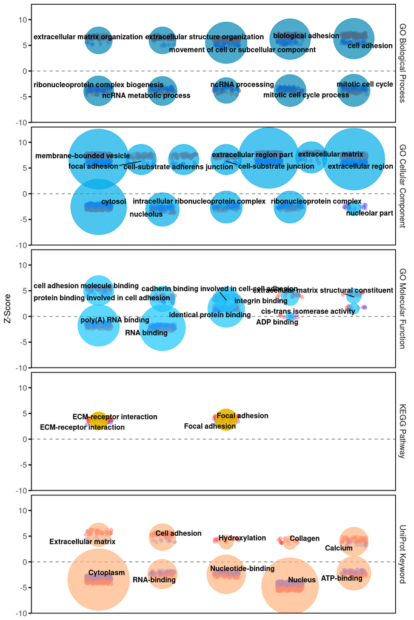

```r
# join it to the GOplot data
go_data <- go_data[go_data$term %in% cat.sub$term,]
go_data<-left_join(go_data, cat.sub)
# for colouring the small points (genes) accordingly
go_data$fill<-NA
go_data[go_data$logFC>0,]$fill<-"up"
go_data[go_data$logFC<0,]$fill<-"down"

# and set the y-variable for the plot from the zscore
go_data$y<-go_data$zscore
go_data[go_data$logFC>0,]$y<-go_data[go_data$logFC>0,]$y*1.1
go_data[go_data$logFC<0,]$y<-go_data[go_data$logFC<0,]$y*0.9

# remove small cell lung cancer annotation as it's not relevant
cat.sub<-cat.sub[cat.sub$term!= "Small cell lung cancer",]
go_data<-go_data[go_data$term!= "Small cell lung cancer",]
cat.sub$text_y<-cat.sub$zscore*0.95

# make the facet labels pretty
rename.cat <- c("GO Cellular Component", "GO Biological Process", "GO Molecular Function", "UniProt Keyword", "KEGG Pathway")
names(rename.cat) <- c("GOTERM_CC_FAT", "GOTERM_BP_FAT", "GOTERM_MF_FAT", "UP_KEYWORDS", "KEGG_PATHWAY")

funct_annot_plot <-
  ggplot() +
  geom_hline(yintercept =0, linetype =2, alpha = 0.5)+ # a horizontal line at zscore = 0
  geom_jitter(data=go_data, mapping=aes(y=y, x=num, color = fill), size =2, height = 0.5, width =5, alpha =1/3)+ # the small bubbles of the genes
  scale_color_manual("logFC", values = c("#3333ff", "#ff3333"), guide="none") +
  new_scale_color() + # use the ggnewscale package to adjust the colours for the small and the big bubbles
  geom_point(data = cat.sub, mapping = aes(y=zscore, x=num, size = count, color = category), alpha =0.7) + # big bubbles describing the annotation terms
  scale_size(range = c(5,40), guide = 'none') +
  scale_color_manual("Category", values = c("#0086b3","#00ace6", "#1ac6ff", "#e6b800", "#ffb380"), guide = "none") +
  geom_text_repel(data=cat.sub, aes(x=num, y=text_y, label = term), fontface=2, size = 3.5) + # the ggrepel packages helps with the annotation
  scale_x_continuous("", limits = c(-20,110))+
  scale_y_continuous(limits =c (-9,12))+
  guides(shape = guide_legend(override.aes = list(size = 2)))+
  ylab("Z-Score") +
  facet_grid(category~., space="free", labeller = labeller(category = rename.cat))+
  theme_minimal() +
  theme(
  axis.title.x=element_blank(),
  axis.text.x=element_blank(),
  axis.ticks.x=element_blank(),
  axis.text = element_text(size = 9),
  title =  element_text(size = 10),
  axis.title = element_text(size = 12),
  axis.text.y =  element_text(size = 11),
  strip.text = element_text(size = 11),
  legend.text = element_text(size = 10),
  legend.title = element_text(size = 10),
  axis.title.y = element_text(margin = margin(t = 0, r = 5, b = 0, l = 0)),
  axis.ticks.length=unit(.125, "cm"),
  rect = element_rect(fill = "transparent"),
  plot.background = element_rect(fill = "transparent",color = NA),
  panel.grid.minor = element_blank(),
  panel.grid.major = element_blank(),
  panel.border = element_rect(size=1),
  axis.ticks = element_line(colour = "black", size = 0.75),
  strip.background =element_rect(fill="transparent", color = 'transparent'),
)

print(funct_annot_plot)
```

For longer annotation terms, it might be worthwhile to include linebreaks (`\n`) manually:

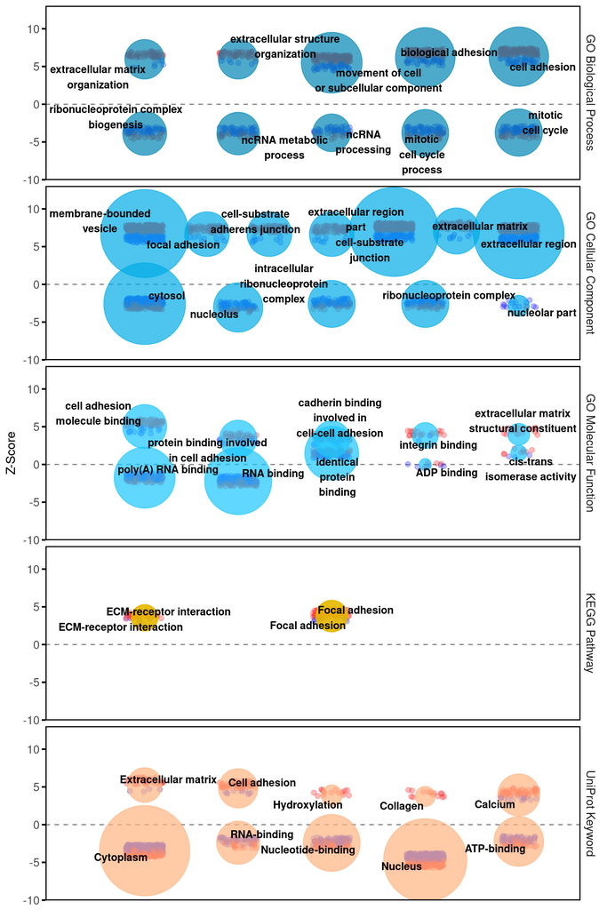

```r
cat.sub[cat.sub$term == "cell adhesion molecule binding",]$term<-"cell adhesion\nmolecule binding"
cat.sub[cat.sub$term == "protein binding involved in cell adhesion",]$term<-"protein binding involved\nin cell adhesion"
cat.sub[cat.sub$term == "cadherin binding involved in cell-cell adhesion",]$term<-"cadherin binding\ninvolved in\ncell-cell adhesion"
cat.sub[cat.sub$term == "extracellular matrix structural constituent",]$term<-"extracellular matrix\nstructural constituent"
cat.sub[cat.sub$term == "movement of cell or subcellular component",]$term<-"movement of cell\nor subcellular component"
cat.sub[cat.sub$term == "integrin binding",]$term<-"integrin binding"
cat.sub[cat.sub$term == "identical protein binding",]$term<-"identical\nprotein\nbinding"
cat.sub[cat.sub$term == "membrane-bounded vesicle",]$term <-"membrane-bounded\nvesicle"
cat.sub[cat.sub$term == "cell-substrate adherens junction",]$term<-"cell-substrate\nadherens junction"
cat.sub[cat.sub$term == "extracellular matrix organization",]$term<-"extracellular matrix\norganization"
cat.sub[cat.sub$term == "extracellular structure organization",]$term<-"extracellular structure\norganization"
cat.sub[cat.sub$term == "intracellular ribonucleoprotein complex",]$term<-"intracellular\nribonucleoprotein\ncomplex"
cat.sub[cat.sub$term == "ribonucleoprotein complex biogenesis",]$term<-"ribonucleoprotein complex\nbiogenesis"
cat.sub[cat.sub$term == "ribonucleoprotein complex",]$term<-"ribonucleoprotein complex"
cat.sub[cat.sub$term == "mitotic cell cycle process",]$term<-"mitotic\ncell cycle\nprocess"
cat.sub[cat.sub$term == "mitotic cell cycle",]$term<-"mitotic\ncell cycle"
cat.sub[cat.sub$term == "ncRNA metabolic process",]$term<-"ncRNA metabolic\nprocess"
cat.sub[cat.sub$term == "ncRNA processing",]$term<-"ncRNA\nprocessing"
cat.sub[cat.sub$term == "cis-trans isomerase activity",]$term<-"cis-trans\nisomerase activity"
cat.sub[cat.sub$term == "extracellular region part",]$term<-"extracellular region\npart"
cat.sub[cat.sub$term == "cell-substrate junction",]$term<-"cell-substrate\njunction"

funct_annot_plot <-
  ggplot() +
  geom_hline(yintercept =0, linetype =2, alpha = 0.5)+
  geom_jitter(data=go_data, mapping=aes(y=y, x=num, color = fill), size =2, height = 0.5, width =5, alpha =1/3)+ #smake the small bubble of the genes
  scale_color_manual("logFC", values = c("#3333ff", "#ff3333"), guide="none") +
  new_scale_color() + # use the ggnewscale package to adjust the colours for the small and the big bubbles
  geom_point(data = cat.sub, mapping = aes(y=zscore, x=num, size = count, color = category), alpha =0.7) + # big bubbles describing the annotation terms
  scale_size(range = c(5,40), guide = 'none') +
  scale_color_manual("Category", values = c("#0086b3","#00ace6", "#1ac6ff", "#e6b800", "#ffb380"), guide = "none") +
  geom_text_repel(data=cat.sub, aes(x=num, y=text_y, label = term), fontface=2, size = 3.5) + # the ggrepel packages helps with the annotation
  scale_x_continuous("", limits = c(-20,110))+
  scale_y_continuous(limits =c (-9,12))+
  guides(shape = guide_legend(override.aes = list(size = 2)))+
  ylab("Z-Score") +
  facet_grid(category~., space="free", labeller = labeller(category = rename.cat))+
  theme_minimal() +
  theme(
    axis.title.x=element_blank(),
    axis.text.x=element_blank(),
    axis.ticks.x=element_blank(),
    axis.text = element_text(size = 9),
    title =  element_text(size = 10),
    axis.title = element_text(size = 12),
    axis.text.y =  element_text(size = 11),
    strip.text = element_text(size = 11),
    legend.text = element_text(size = 10),
    legend.title = element_text(size = 10),
    axis.title.y = element_text(margin = margin(t = 0, r = 5, b = 0, l = 0)),
    axis.ticks.length=unit(.125, "cm"),
    rect = element_rect(fill = "transparent"),
    plot.background = element_rect(fill = "transparent",color = NA),
    panel.grid.minor = element_blank(),
    panel.grid.major = element_blank(),
    panel.border = element_rect(size=1),
    axis.ticks = element_line(colour = "black", size = 0.75),
    strip.background =element_rect(fill="transparent", color = 'transparent'),
  )

print(funct_annot_plot)
```

Pretty functional annotation plot :)

The small blue and red dots represent genes, coloured according to their logFC. The big bubbles represent annotation terms with the size depending on the counts.

## Functional Annotation clustering

In addition to functional annotation of gene list, DAVID provides a tool to cluster these annotation terms.

```r
# create an annotation cluster object
annot_cluster <- getClusterReport(david,
                                  overlap=4L,
                                  initialSeed=4L,
                                  finalSeed=4L,
                                  linkage=0.5,
                                  kappa=35L)

# use getClusterReportFile to save the results to a file

head(summary(annot_cluster))
```

```
##   Cluster Enrichment Members
## 1       1  17.552546       6
## 2       2   9.149228      16
## 3       3   6.549032      15
## 4       4   5.573421      15
## 5       5   5.121968      10
## 6       6   4.708047      24
```

Pick out the clusters which are of interest. Here, we use the top 5 according to the enrichment.

```r
cluster_interest<-head(summary(annot_cluster))%>%top_n(5, Enrichment)

# nake a data frane to use in the plot
cl_df_complete<-NULL
# loop through cluster of interest and combine the information
for (coi in cluster_interest$Cluster){
  l<-(annot_cluster@cluster[[coi]]$Members)
  cl.df<-t(as.data.frame(t(as.data.frame(l))))
  cl.df<-as.data.frame(cl.df)
  cl.df$clusterno<-coi
  cl.df$EnrichScore<-annot_cluster@cluster[[coi]]$EnrichmentScore
  cl_df_complete<-rbind(cl_df_complete, cl.df)
}

# some cleaning up for the plot
cl_df_complete$Count<-as.numeric(as.character(cl_df_complete$Count))
cl_df_complete$clusterno<-ordered(cl_df_complete$clusterno)
cl_df_complete$alpha<-ave(cl_df_complete$Count, cl_df_complete$clusterno, FUN=seq_along)
cl_df_complete$clusterinfo<-paste("Cluster:", cl_df_complete$clusterno, " Enrichment Score: ", round(cl_df_complete$EnrichScore,2), sep = " ")
cl_df_complete$TermInfo<-gsub("^.*~", "", cl_df_complete$Term)
head(cl_df_complete, 1)
```

```
##        Category                             Term Count       X.       PValue
## 1 GOTERM_CC_FAT GO:1903561~extracellular vesicle   329 30.04566 2.222143e-24
##                                                                                                                                                                                                                                                                                                          …
## 1 P16278, P07437, P13987, Q7L9L4, Q7Z3B1, Q13867, O60613, Q99988, Q01831, P04216, Q9H1J7, P61077, Q9NQW7, Q11201, P61764, O60716, O75695, P62857, Q15075, Q9UHL4, P98160, P22694, Q96J02, Q04828, P10619, P78324, P00352, Q9NR99, Q86V48, P13073, Q8IUX7, O15230, Q07812, Q9H3K6, P07237, Q5T749, P98172,…
##   List.Total Pop.Hits Pop.Total Fold.Enrichment   Bonferroni    Benjamini
## 1       1017     2825     14527        1.663537 2.155479e-21 2.155479e-21
##            FDR clusterno EnrichScore alpha                          clusterinfo
## 1 3.497291e-21         1    17.55255     1 Cluster: 1  Enrichment Score:  17.55
##                TermInfo
## 1 extracellular vesicle
```

Create a function for the lollipop plot.

```r
cl_annot_plot <- function(df, cols, rename.cols) {
  p <-   ggplot(df, aes(x = reorder(TermInfo, Count), y = Count)) +
    geom_segment(aes(
      xend = TermInfo,
      y = 0,
      yend = Count,
      color = Category
    ), size = 2) +
    geom_point(size = 4, alpha = 1, aes(color = Category)) +
    geom_text (
      aes(label = TermInfo, y = 1),
      hjust = 0,
      vjust = 1,
      stat = 'identity',
      check_overlap = TRUE,
      fontface = 2,
      nudge_x = -0.15
    ) +
    coord_flip() +
    scale_color_manual(values = cols,
                       labels = rename.cols,
                       drop = F) +
    ylab("Count") +
    facet_grid(clusterinfo ~ .,
               scales = "free_y",
               space = "free",
               switch = 'y') +
    theme_bw() +
    theme(
      axis.text.y = element_blank(),
      legend.position = "none",
      axis.title.y = element_blank(),
      axis.ticks.y = element_blank(),
      axis.text = element_text(size = 10),
      title =  element_text(size = 10),
      axis.title = element_text(size = 12),
      strip.text = element_text(size = 11, face = 2),
      legend.text = element_text(size = 10),
      legend.title = element_text(size = 10),
      axis.ticks.length = unit(.125, "cm"),
      rect = element_rect(fill = "transparent"),
      plot.background = element_rect(fill = "transparent", color = NA),
      panel.grid.minor = element_blank(),
      panel.grid.major = element_blank(),
      panel.border = element_rect(size = 1),
      axis.ticks = element_line(colour = "black", size = 0.75),
      strip.background = element_rect(fill = "transparent", color = 'transparent'),
      legend.key = element_rect(fill = 'transparent', color = NA)
    )
  return(p)
}
```

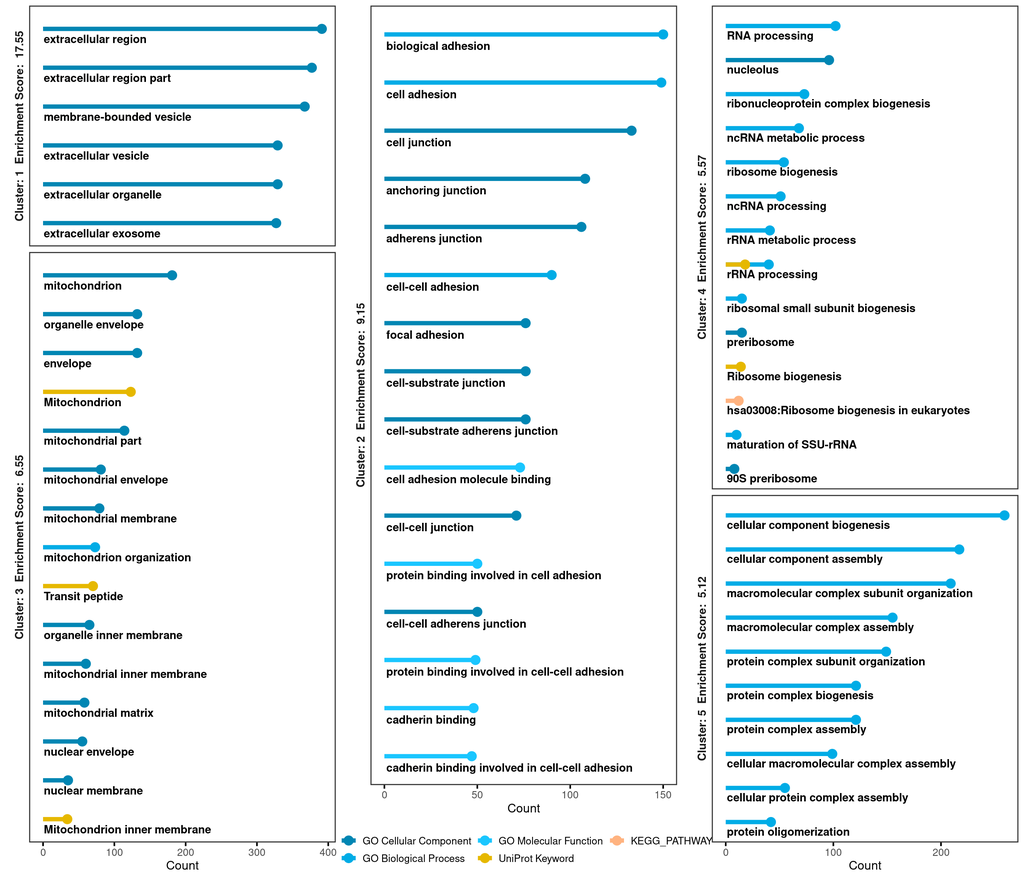

```r
# rename the categories in the plot to make them lok pretty
rename.cat <-  c("GO Cellular Component", "GO Biological Process", "GO Molecular Function", "UniProt Keyword", 'KEGG Pathway')
names(rename.cat) <- c("GOTERM_CC_FAT", "GOTERM_BP_FAT", "GOTERM_MF_FAT", "UP_KEYWORDS", "KEGG_Pathway")

# pretty colours
my_cols <- c("#0086b3","#00ace6", "#1ac6ff", "#e6b800", "#ffb380", 'red')
names(my_cols)<- names(rename.cat)
#names(my_cols)<-c("GO Cellular Component", "GO Biological Process", "GO Molecular Function", "UniProt Keyword", "KEGG Pathway")

# manually arrange the subplots of the clusters
t <- arrangeGrob(
  cl_annot_plot(cl_df_complete[cl_df_complete$clusterno%in%c(1,3),], cols = my_cols, rename.cols = rename.cat),
  cl_annot_plot(cl_df_complete[cl_df_complete$clusterno%in%c(2),], cols = my_cols, rename.cols = rename.cat) +
    guides(color=guide_legend(ncol=3, title = '')) + theme(legend.position = 'bottom'),
  cl_annot_plot(cl_df_complete[cl_df_complete$clusterno%in%c(4,5),], cols = my_cols, rename.cols = rename.cat),
  ncol=3)

grid.draw(t)
```

```r
# use ggsave() to save the graph
```

Pretty Plot :)

# References

```r
for (i in packages){
  print(citation(i))
}
```

```
##
##
##   Philipp Schauberger and Alexander Walker (2020). openxlsx: Read,
##   Write and Edit xlsx Files. R package version 4.1.5.
##   https://CRAN.R-project.org/package=openxlsx
##
## A BibTeX entry for LaTeX users is
##
##   @Manual{,
##     title = {openxlsx: Read, Write and Edit xlsx Files},
##     author = {Philipp Schauberger and Alexander Walker},
##     year = {2020},
##     note = {R package version 4.1.5},
##     url = {https://CRAN.R-project.org/package=openxlsx},
##   }
##
##
##
##   Cristobal Fresno, Elmer A. Fernandez (2013). RDAVIDWebService: a
##   versatile R interface to DAVID Bioinformatics, 29(21), 2810-2811. URL
##   http://bioinformatics.oxfordjournals.org/content/29/21/2810.
##
## A BibTeX entry for LaTeX users is
##
##   @Article{,
##     title = {{RDAVIDWebService}: a versatile {R} interface to {DAVID}},
##     author = {Crist\'{o}bal Fresno and Elmer A. Fern\'{a}ndez},
##     journal = {Bioinformatics},
##     year = {2013},
##     volume = {29},
##     number = {21},
##     pages = {2810--2811},
##     url = {http://bioinformatics.oxfordjournals.org/content/29/21/2810},
##   }
##
##
##
##   Walter, Wencke, Fatima Sanchez-Cabo, and Mercedes Ricote. GOplot: an
##   R package for visually combining expression data with functional
##   analysis. Bioinformatics (2015): btv300.
```

[output cut: 97 more lines]

```
##
## A BibTeX entry for LaTeX users is
##
##   @Manual{,
##     title = {R: A Language and Environment for Statistical Computing},
##     author = {{R Core Team}},
##     organization = {R Foundation for Statistical Computing},
##     address = {Vienna, Austria},
##     year = {2020},
##     url = {https://www.R-project.org/},
##   }
##
## We have invested a lot of time and effort in creating R, please cite it
## when using it for data analysis. See also 'citation("pkgname")' for
## citing R packages.
```